# Lab 02

# 0.

## Import the data and declare your package dependencies.

I am importing pandas to clean and pivot the datasets(avocado, housing prices), numpy to do calculations on the datasets, and plotnine library to provide visual data through graphs in this lab.

Below is the original avocado dataset

```python
import pandas as pd
import numpy as np
import plotnine as p9
pd.options.display.float_format = '{:,.2f}'.format
df_avacados = pd.read_csv('avocado-updated-2020.csv')
df_avacados
```

|  | date | average_price | total_volume | 4046 | 4225 | 4770 | total_bags | small_bags | large_bags | xlarge_bags | type | year | geography |
| --- | --- | --- | --- | --- | --- | --- | --- | --- | --- | --- | --- | --- | --- |
| 0 | 2015-01-04 | 1.22 | 40,873.28 | 2,819.50 | 28,287.42 | 49.90 | 9,716.46 | 9,186.93 | 529.53 | 0.00 | conventional | 2015 | Albany |
| 1 | 2015-01-04 | 1.79 | 1,373.95 | 57.42 | 153.88 | 0.00 | 1,162.65 | 1,162.65 | 0.00 | 0.00 | organic | 2015 | Albany |
| 2 | 2015-01-04 | 1.00 | 435,021.49 | 364,302.39 | 23,821.16 | 82.15 | 46,815.79 | 16,707.15 | 30,108.64 | 0.00 | conventional | 2015 | Atlanta |
| 3 | 2015-01-04 | 1.76 | 3,846.69 | 1,500.15 | 938.35 | 0.00 | 1,408.19 | 1,071.35 | 336.84 | 0.00 | organic | 2015 | Atlanta |
| 4 | 2015-01-04 | 1.08 | 788,025.06 | 53,987.31 | 552,906.04 | 39,995.03 | 141,136.68 | 137,146.07 | 3,990.61 | 0.00 | conventional | 2015 | Baltimore/Washington |
| ... | ... | ... | ... | ... | ... | ... | ... | ... | ... | ... | ... | ... | ... |
| 33040 | 2020-11-29 | 1.47 | 1,583,056.27 | 67,544.48 | 97,996.46 | 2,617.17 | 1,414,878.10 | 906,711.52 | 480,191.83 | 27,974.75 | organic | 2020 | Total U.S. |
| 33041 | 2020-11-29 | 0.91 | 5,811,114.22 | 1,352,877.53 | 589,061.83 | 19,741.90 | 3,790,665.29 | 2,197,611.02 | 1,531,530.14 | 61,524.13 | conventional | 2020 | West |
| 33042 | 2020-11-29 | 1.48 | 289,961.27 | 13,273.75 | 19,341.09 | 636.51 | 256,709.92 | 122,606.21 | 134,103.71 | 0.00 | organic | 2020 | West |
| 33043 | 2020-11-29 | 0.67 | 822,818.75 | 234,688.01 | 80,205.15 | 10,543.63 | 497,381.96 | 285,764.11 | 210,808.02 | 809.83 | conventional | 2020 | West Tex/New Mexico |
| 33044 | 2020-11-29 | 1.35 | 24,106.58 | 1,236.96 | 617.80 | 1,564.98 | 20,686.84 | 17,824.52 | 2,862.32 | 0.00 | organic | 2020 | West Tex/New Mexico |

33045 rows × 13 columns

# 1.

## Briefly describe the data set. What information does it contain?

This dataset provides metrics for avacodos weekely sales from 2015 to 2020 (formerly it had data only till 2018, but it got updated to include years after 2018), specially focusing on ‘when’ it was sold (years), ‘how’ much was sold on average(weekly prices and sales volumes), how many were sold based on catagorizes like avocado sizes, bag sized bags, and if they were organic or non-organic, ‘where’ they were sold (location) as defined in the “geography” column. The geography column contain wide range of cities and regions allowing for detailed geographic analysis.

# 2.

## Clean the data in any way you see fit.

Let’s clean the dataset in step by first understanding what it contains then figuring out what needs to be changed for analysis.

##### 1. Understanding the data (column name, types, checking missing values, duplicates)

```python
print(df_avacados.dtypes)
# Convert 'date' column to datetime
df_avacados['date'] = pd.to_datetime(df_avacados['date'], errors='coerce')    #errors='coerce' specially for pd.to_datetime(missing = NaN)
# Check
df_avacados.drop_duplicates()
df_avacados.dropna()
print(df_avacados.isnull().sum())    #missing values for new dataframe
```

```
date              object
average_price    float64
total_volume     float64
4046             float64
4225             float64
4770             float64
total_bags       float64
small_bags       float64
large_bags       float64
xlarge_bags      float64
type              object
year               int64
geography         object
dtype: object
date             0
average_price    0
total_volume     0
4046             0
4225             0
4770             0
total_bags       0
small_bags       0
large_bags       0
xlarge_bags      0
type             0
year             0
geography        0
dtype: int64
```

As the date column was in object format, we changed it into datetime format for convenience.

We also dropped duplicates adn missing values, but this dataset interestingly had no missing or duplicate values, which is uncommon in real world datasets.

```python
# reference code for part 3(below)
#counting_volume_on_original_dataframe = df_avacados.groupby('geography')['total_volume'].sum().reset_index()
#counting_volume_on_original_dataframe
```

##### 2. Renaming confusing columns and melting the data (‘4046’, ‘4225’, ‘4770’)

```python
# 1. Rename confusing columns
df_avacados = df_avacados.rename(columns={
    "4046": "small",
    "4225": "large",
    '4770': "extra_large",
    'geography' : 'location'
})

# 2. Melt the data
avocado_clean = df_avacados.melt(
    # all identifier columns
    id_vars=["date", "average_price", "type", "location", "total_volume", "total_bags", "small_bags", "large_bags", "xlarge_bags"],

    # columns we want to unpivot
    value_vars=["small", "large", "extra_large"],

    var_name="hass_avacado_size",          # Renamed to be more precise
    value_name="quantity_sold"        # Name for the new column holding the actual count
)

# Now, avocado_clean is in a "long" format and ready for analysis.
avocado_clean
```

|  | date | average_price | type | location | total_volume | total_bags | small_bags | large_bags | xlarge_bags | hass_avacado_size | quantity_sold |
| --- | --- | --- | --- | --- | --- | --- | --- | --- | --- | --- | --- |
| 0 | 2015-01-04 | 1.22 | conventional | Albany | 40,873.28 | 9,716.46 | 9,186.93 | 529.53 | 0.00 | small | 2,819.50 |
| 1 | 2015-01-04 | 1.79 | organic | Albany | 1,373.95 | 1,162.65 | 1,162.65 | 0.00 | 0.00 | small | 57.42 |
| 2 | 2015-01-04 | 1.00 | conventional | Atlanta | 435,021.49 | 46,815.79 | 16,707.15 | 30,108.64 | 0.00 | small | 364,302.39 |
| 3 | 2015-01-04 | 1.76 | organic | Atlanta | 3,846.69 | 1,408.19 | 1,071.35 | 336.84 | 0.00 | small | 1,500.15 |
| 4 | 2015-01-04 | 1.08 | conventional | Baltimore/Washington | 788,025.06 | 141,136.68 | 137,146.07 | 3,990.61 | 0.00 | small | 53,987.31 |
| ... | ... | ... | ... | ... | ... | ... | ... | ... | ... | ... | ... |
| 99130 | 2020-11-29 | 1.47 | organic | Total U.S. | 1,583,056.27 | 1,414,878.10 | 906,711.52 | 480,191.83 | 27,974.75 | extra_large | 2,617.17 |
| 99131 | 2020-11-29 | 0.91 | conventional | West | 5,811,114.22 | 3,790,665.29 | 2,197,611.02 | 1,531,530.14 | 61,524.13 | extra_large | 19,741.90 |
| 99132 | 2020-11-29 | 1.48 | organic | West | 289,961.27 | 256,709.92 | 122,606.21 | 134,103.71 | 0.00 | extra_large | 636.51 |
| 99133 | 2020-11-29 | 0.67 | conventional | West Tex/New Mexico | 822,818.75 | 497,381.96 | 285,764.11 | 210,808.02 | 809.83 | extra_large | 10,543.63 |
| 99134 | 2020-11-29 | 1.35 | organic | West Tex/New Mexico | 24,106.58 | 20,686.84 | 17,824.52 | 2,862.32 | 0.00 | extra_large | 1,564.98 |

99135 rows × 11 columns

##### 3. ‘Mapping’ new columns from geography column (added geo_type column with ‘city’, ‘region’, ‘total US’ values)

```python
#create geo_type dictionary for (city, state, region, us)
geo_type_map = {
    # --- NATIONAL LEVEL ---
    'Total U.S.': 'US',

    # --- STATE/LARGE AREAS (often treated as large regions) ---
    'California': 'State',
    'South Carolina': 'State',

    # --- REGIONAL AGGREGATES (Broad marketing regions) ---
    'West': 'Region',
    'Northeast': 'Region',
    'South': 'Region',  # Note: 'South' is implied by the HAB groupings
    'Midwest': 'Region', # Note: 'Midwest' is implied by the HAB groupings
    'Great Lakes': 'Region',
    'Midsouth': 'Region',
    'Plains': 'Region',
    'South Central': 'Region',
    'Southeast': 'Region',
    'Northern New England': 'Region',
    'West Tex/New Mexico': 'Region',

    # --- CITY/METRO AREAS (Specific markets) ---
    'Albany': 'City', 'Atlanta': 'City', 'Baltimore/Washington': 'City', 'Boise': 'City',
    'Boston': 'City', 'Buffalo/Rochester': 'City', 'Charlotte': 'City', 'Chicago': 'City',
    'Cincinnati/Dayton': 'City', 'Columbus': 'City', 'Dallas/Ft. Worth': 'City',
    'Denver': 'City', 'Detroit': 'City', 'Grand Rapids': 'City', 'Harrisburg/Scranton': 'City',
    'Hartford/Springfield': 'City', 'Houston': 'City', 'Indianapolis': 'City',
    'Jacksonville': 'City', 'Las Vegas': 'City', 'Los Angeles': 'City', 'Louisville': 'City',
    'Miami/Ft. Lauderdale': 'City', 'Nashville': 'City', 'New Orleans/Mobile': 'City',
    'New York': 'City', 'Orlando': 'City', 'Philadelphia': 'City', 'Phoenix/Tucson': 'City',
    'Pittsburgh': 'City', 'Portland': 'City', 'Raleigh/Greensboro': 'City', 'Richmond/Norfolk': 'City',
    'Roanoke': 'City', 'Sacramento': 'City', 'San Diego': 'City', 'San Francisco': 'City',
    'Seattle': 'City', 'Spokane': 'City', 'St. Louis': 'City', 'Syracuse': 'City', 'Tampa': 'City'
}

#map function to map the dictionary values into a new column
avocado_clean['geo_type'] = avocado_clean['location'].map(geo_type_map)
# 3. Verify the result
print(avocado_clean['geo_type'].value_counts())
print(avocado_clean['geo_type'].isnull().sum())
#had 1826 unmapped values of Tampa, fixed in the next code.
avocado_clean
```

```
geo_type
City      77112
Region    16515
State      3672
US         1836
Name: count, dtype: int64
0
```

|  | date | average_price | type | location | total_volume | total_bags | small_bags | large_bags | xlarge_bags | hass_avacado_size | quantity_sold | geo_type |
| --- | --- | --- | --- | --- | --- | --- | --- | --- | --- | --- | --- | --- |
| 0 | 2015-01-04 | 1.22 | conventional | Albany | 40,873.28 | 9,716.46 | 9,186.93 | 529.53 | 0.00 | small | 2,819.50 | City |
| 1 | 2015-01-04 | 1.79 | organic | Albany | 1,373.95 | 1,162.65 | 1,162.65 | 0.00 | 0.00 | small | 57.42 | City |
| 2 | 2015-01-04 | 1.00 | conventional | Atlanta | 435,021.49 | 46,815.79 | 16,707.15 | 30,108.64 | 0.00 | small | 364,302.39 | City |
| 3 | 2015-01-04 | 1.76 | organic | Atlanta | 3,846.69 | 1,408.19 | 1,071.35 | 336.84 | 0.00 | small | 1,500.15 | City |
| 4 | 2015-01-04 | 1.08 | conventional | Baltimore/Washington | 788,025.06 | 141,136.68 | 137,146.07 | 3,990.61 | 0.00 | small | 53,987.31 | City |
| ... | ... | ... | ... | ... | ... | ... | ... | ... | ... | ... | ... | ... |
| 99130 | 2020-11-29 | 1.47 | organic | Total U.S. | 1,583,056.27 | 1,414,878.10 | 906,711.52 | 480,191.83 | 27,974.75 | extra_large | 2,617.17 | US |
| 99131 | 2020-11-29 | 0.91 | conventional | West | 5,811,114.22 | 3,790,665.29 | 2,197,611.02 | 1,531,530.14 | 61,524.13 | extra_large | 19,741.90 | Region |
| 99132 | 2020-11-29 | 1.48 | organic | West | 289,961.27 | 256,709.92 | 122,606.21 | 134,103.71 | 0.00 | extra_large | 636.51 | Region |
| 99133 | 2020-11-29 | 0.67 | conventional | West Tex/New Mexico | 822,818.75 | 497,381.96 | 285,764.11 | 210,808.02 | 809.83 | extra_large | 10,543.63 | Region |
| 99134 | 2020-11-29 | 1.35 | organic | West Tex/New Mexico | 24,106.58 | 20,686.84 | 17,824.52 | 2,862.32 | 0.00 | extra_large | 1,564.98 | Region |

99135 rows × 12 columns

Created a dictionary to segregate the ‘location’ column to create another column ‘geo_type’ to divide locations into ‘city’, ‘state’, ‘region’, and ‘US’ fo easier analysis.

Verified if we missed any location for our new geo_type columns(used gemini to create the dictionary, and it missed Tampa region, which i had to add into ‘south’ again.)

##### 4. Standardize ‘location’ column values to title case for consistency

```python
# Standardize 'location' to lowercase
avocado_clean['location'] = avocado_clean['location'].str.title()

# Check unique values to find any remaining inconsistencies
print(avocado_clean['location'].unique())
```

```
['Albany' 'Atlanta' 'Baltimore/Washington' 'Boise' 'Boston'
 'Buffalo/Rochester' 'California' 'Charlotte' 'Chicago'
 'Cincinnati/Dayton' 'Columbus' 'Dallas/Ft. Worth' 'Denver' 'Detroit'
 'Grand Rapids' 'Great Lakes' 'Harrisburg/Scranton' 'Hartford/Springfield'
 'Houston' 'Indianapolis' 'Jacksonville' 'Las Vegas' 'Los Angeles'
 'Louisville' 'Miami/Ft. Lauderdale' 'Midsouth' 'Nashville'
 'New Orleans/Mobile' 'New York' 'Northeast' 'Northern New England'
 'Orlando' 'Philadelphia' 'Phoenix/Tucson' 'Pittsburgh' 'Plains'
 'Portland' 'Raleigh/Greensboro' 'Richmond/Norfolk' 'Roanoke' 'Sacramento'
 'San Diego' 'San Francisco' 'Seattle' 'South Carolina' 'South Central'
 'Southeast' 'Spokane' 'St. Louis' 'Syracuse' 'Tampa' 'Total U.S.' 'West'
 'West Tex/New Mexico']
```

# 3

## Which major geographical region sold the most total organic, small Hass avocados in 2017?

Created granular region mapping to segregate major US regions as well(added column “granular_region”).

```python
# The 11 distinct regions used in geo_type_map
granular_region_mapping = {
    # NORTHEAST REGION
    'Albany': 'Northern New England', 'Boston': 'Northern New England', 'Buffalo/Rochester': 'Northeast', 'Harrisburg/Scranton': 'Northeast', 'Hartford/Springfield': 'Northeast', 'New York': 'Northeast', 'Northern New England': 'Northern New England', 'Philadelphia': 'Northeast', 'Pittsburgh': 'Northeast', 'Syracuse': 'Northeast', 'Northeast': 'Northeast',

    # MIDWEST REGION
    'Chicago': 'Great Lakes', 'Cincinnati/Dayton': 'Great Lakes', 'Columbus': 'Great Lakes', 'Detroit': 'Great Lakes', 'Grand Rapids': 'Great Lakes', 'Indianapolis': 'Great Lakes', 'Louisville': 'Midsouth', 'St. Louis': 'Plains', 'Great Lakes': 'Great Lakes', 'Plains': 'Plains', 'Midwest': 'Plains',

    # SOUTH REGION
    'Atlanta': 'Southeast', 'Baltimore/Washington': 'Southeast', 'Charlotte': 'Southeast', 'Dallas/Ft. Worth': 'South Central', 'Houston': 'South Central', 'Jacksonville': 'Southeast', 'Miami/Ft. Lauderdale': 'Southeast', 'Nashville': 'Midsouth', 'New Orleans/Mobile': 'Midsouth', 'Orlando': 'Southeast', 'Raleigh/Greensboro': 'Southeast', 'Richmond/Norfolk': 'Southeast', 'Roanoke': 'Southeast', 'South Carolina': 'Southeast', 'Midsouth': 'Midsouth', "Tampa" : "Southeast", 'South': 'Southeast', 'South Central': 'South Central', 'Southeast': 'Southeast',

    # WEST REGION
    'Boise': 'West', 'California': 'West', 'Denver': 'West', 'Las Vegas': 'West', 'Los Angeles': 'West', 'Phoenix/Tucson': 'West', 'Portland': 'West', 'Sacramento': 'West', 'San Diego': 'West', 'San Francisco': 'West', 'Seattle': 'West', 'Spokane': 'West', 'West': 'West', 'West Tex/New Mexico': 'West Tex/New Mexico',

    # NATIONAL TOTAL
    'Total U.S.': 'National'
}

# new mapping to a new column
avocado_clean['granular_region'] = avocado_clean['location'].map(granular_region_mapping)
avocado_clean
```

|  | date | average_price | type | location | total_volume | total_bags | small_bags | large_bags | xlarge_bags | hass_avacado_size | quantity_sold | geo_type | granular_region |
| --- | --- | --- | --- | --- | --- | --- | --- | --- | --- | --- | --- | --- | --- |
| 0 | 2015-01-04 | 1.22 | conventional | Albany | 40,873.28 | 9,716.46 | 9,186.93 | 529.53 | 0.00 | small | 2,819.50 | City | Northern New England |
| 1 | 2015-01-04 | 1.79 | organic | Albany | 1,373.95 | 1,162.65 | 1,162.65 | 0.00 | 0.00 | small | 57.42 | City | Northern New England |
| 2 | 2015-01-04 | 1.00 | conventional | Atlanta | 435,021.49 | 46,815.79 | 16,707.15 | 30,108.64 | 0.00 | small | 364,302.39 | City | Southeast |
| 3 | 2015-01-04 | 1.76 | organic | Atlanta | 3,846.69 | 1,408.19 | 1,071.35 | 336.84 | 0.00 | small | 1,500.15 | City | Southeast |
| 4 | 2015-01-04 | 1.08 | conventional | Baltimore/Washington | 788,025.06 | 141,136.68 | 137,146.07 | 3,990.61 | 0.00 | small | 53,987.31 | City | Southeast |
| ... | ... | ... | ... | ... | ... | ... | ... | ... | ... | ... | ... | ... | ... |
| 99130 | 2020-11-29 | 1.47 | organic | Total U.S. | 1,583,056.27 | 1,414,878.10 | 906,711.52 | 480,191.83 | 27,974.75 | extra_large | 2,617.17 | US | National |
| 99131 | 2020-11-29 | 0.91 | conventional | West | 5,811,114.22 | 3,790,665.29 | 2,197,611.02 | 1,531,530.14 | 61,524.13 | extra_large | 19,741.90 | Region | West |
| 99132 | 2020-11-29 | 1.48 | organic | West | 289,961.27 | 256,709.92 | 122,606.21 | 134,103.71 | 0.00 | extra_large | 636.51 | Region | West |
| 99133 | 2020-11-29 | 0.67 | conventional | West Tex/New Mexico | 822,818.75 | 497,381.96 | 285,764.11 | 210,808.02 | 809.83 | extra_large | 10,543.63 | Region | West Tex/New Mexico |
| 99134 | 2020-11-29 | 1.35 | organic | West Tex/New Mexico | 24,106.58 | 20,686.84 | 17,824.52 | 2,862.32 | 0.00 | extra_large | 1,564.98 | Region | West Tex/New Mexico |

99135 rows × 13 columns

Used the new column “granular_region” to find the region with highest sales.

```python
# ----Find Highest Sales within Granular Regions -----

regional_volume_small = avocado_clean.copy()

# Filter the data (2017 & small & organic)
filtered_data = regional_volume_small[
    (regional_volume_small['hass_avacado_size'] == 'small') &
    (regional_volume_small['date'].dt.year == 2017) &
    (regional_volume_small['type'] == 'organic')
].copy()

# related columns only
filtered_data = filtered_data[
    (filtered_data['geo_type'] == 'Region') | (filtered_data['geo_type'] == 'US')
].copy()

# Group by granular_region
regional_volume_summary = filtered_data.groupby('granular_region')['total_volume'].sum().reset_index()

# Rename the column
regional_volume_summary = regional_volume_summary.rename(columns={'total_volume': 'total_small_units_sold'})

pd.options.display.float_format = '{:,.0f}'.format
print(regional_volume_summary.sort_values(by='total_small_units_sold', ascending=False))
```

```
        granular_region  total_small_units_sold
2              National              62,923,682
8                  West              12,241,846
3             Northeast              11,760,004
0           Great Lakes               8,928,084
6         South Central               7,104,671
1              Midsouth               7,047,686
7             Southeast               4,097,435
5                Plains               3,326,803
4  Northern New England                 935,399
9   West Tex/New Mexico                 919,131
```

### Answer:

Therefore, the major geographical region sold the most total organic, small Hass avocados in 2017 is ‘National’, which sold 62,923,682 units.

# 4.

## Split the date variable into month, day, and year variables. In which month is the highest average volume of avocado sales?

```python
#  'year' column
avocado_clean['year'] = avocado_clean['date'].dt.year

#  'month' column
avocado_clean['month'] = avocado_clean['date'].dt.month

#  'day' column
avocado_clean['day'] = avocado_clean['date'].dt.day

# Display the head of the DataFrame to confirm the new columns
print(avocado_clean[['date', 'year', 'month', 'day']].head())
```

```
        date  year  month  day
0 2015-01-04  2015      1    4
1 2015-01-04  2015      1    4
2 2015-01-04  2015      1    4
3 2015-01-04  2015      1    4
4 2015-01-04  2015      1    4
```

Finding highest average volume of avocado sales

```python
highest_monthly_sles = avocado_clean.groupby('month')['total_volume'].sum()
print(highest_monthly_sles.idxmax())
print(highest_monthly_sles.max())
```

```
5
9829534959.9
```

### Answer:

# 5.

## Which metro area geographical regions sold the most total avocados? Plot side-by-side box-plots of the total volume for only the five metro geographical regions with the highest averages for the total_volume variable.

```python
#filter dataset with geo_type = city only
#using the .copy() method to filter dataframe, making a new dataframe.

# 1. define the filter
city_filter = avocado_clean['geo_type'] == 'City'

# 2. create a copy of original dataframe, apply filter
avocado_clean_city = avocado_clean[city_filter].copy()

# groupby() function to take 2 columns and average the values
total_volume_by_metro = (
    avocado_clean_city.groupby('location')['total_volume']
    .sum()
    .reset_index()                                            #reset index
    .rename(columns={'total_volume': 'total_volume_sold'})    #rename
    .sort_values(by='total_volume_sold', ascending=False))    #descending
total_volume_by_metro
```

|  | location | total_volume_sold |
| --- | --- | --- |
| 20 | Los Angeles | 2,878,051,464 |
| 25 | New York | 1,584,735,733 |
| 10 | Dallas/Ft. Worth | 1,308,612,483 |
| 16 | Houston | 1,262,531,541 |
| 28 | Phoenix/Tucson | 1,147,570,241 |
| 11 | Denver | 833,788,587 |
| 2 | Baltimore/Washington | 830,293,902 |
| 36 | San Francisco | 822,650,665 |
| 7 | Chicago | 772,995,032 |
| 22 | Miami/Ft. Lauderdale | 695,234,546 |
| 30 | Portland | 640,631,323 |
| 4 | Boston | 612,397,557 |
| 37 | Seattle | 607,207,728 |
| 1 | Atlanta | 596,982,353 |
| 35 | San Diego | 521,293,349 |
| 27 | Philadelphia | 475,298,020 |
| 34 | Sacramento | 447,813,947 |
| 41 | Tampa | 445,884,203 |
| 12 | Detroit | 420,068,338 |
| 26 | Orlando | 407,703,950 |
| 19 | Las Vegas | 326,552,257 |
| 31 | Raleigh/Greensboro | 323,937,913 |
| 15 | Hartford/Springfield | 313,814,897 |
| 24 | New Orleans/Mobile | 283,999,715 |
| 14 | Harrisburg/Scranton | 281,929,193 |
| 8 | Cincinnati/Dayton | 278,198,420 |
| 32 | Richmond/Norfolk | 273,749,929 |
| 6 | Charlotte | 243,843,818 |
| 23 | Nashville | 232,361,248 |
| 17 | Indianapolis | 199,217,654 |
| 9 | Columbus | 197,810,249 |
| 39 | St. Louis | 189,492,149 |
| 18 | Jacksonville | 186,622,392 |
| 13 | Grand Rapids | 176,909,392 |
| 33 | Roanoke | 165,531,864 |
| 5 | Buffalo/Rochester | 153,602,772 |
| 29 | Pittsburgh | 123,287,071 |
| 21 | Louisville | 104,678,013 |
| 0 | Albany | 104,449,006 |
| 38 | Spokane | 92,343,002 |
| 3 | Boise | 91,078,658 |
| 40 | Syracuse | 72,386,127 |

### Answer:

Therefore, the metro area geographical regions sold the most total avocados is Los Angeles with 2,878,051,464 sales. For the box plot, we need only 5 top cities (Los Angeles, New York, Dallas/Ft. Worth, Houston, Phoenix/Tucson).

Calculating the average of the top 5 sities:

```python
# AVERAGE Volume for top 5 cities

average_volume_by_metro = (
    avocado_clean_city.groupby('location')['total_volume']
    .mean() # Calculating the MEAN (average) volume
    .sort_values(ascending=False))
average_volume_by_metro
```

```
location
Los Angeles            1,567,566
New York                 863,146
Dallas/Ft. Worth         712,752
Houston                  687,653
Phoenix/Tucson           625,038
Denver                   454,133
Baltimore/Washington     452,230
San Francisco            448,067
Chicago                  421,021
Miami/Ft. Lauderdale     378,668
Portland                 348,928
Boston                   333,550
Seattle                  330,723
Atlanta                  325,154
San Diego                283,929
Philadelphia             258,877
Sacramento               243,907
Tampa                    242,856
Detroit                  228,795
Orlando                  222,061
Las Vegas                177,861
Raleigh/Greensboro       176,437
Hartford/Springfield     170,923
New Orleans/Mobile       154,684
Harrisburg/Scranton      153,556
Cincinnati/Dayton        151,524
Richmond/Norfolk         149,101
Charlotte                132,813
Nashville                126,558
Indianapolis             108,506
Columbus                 107,740
St. Louis                103,209
Jacksonville             101,646
Grand Rapids              96,356
Roanoke                   90,159
Buffalo/Rochester         83,662
Pittsburgh                67,150
Louisville                57,014
Albany                    56,889
Spokane                   50,296
Boise                     49,607
Syracuse                  39,426
Name: total_volume, dtype: float64
```

### Plotting

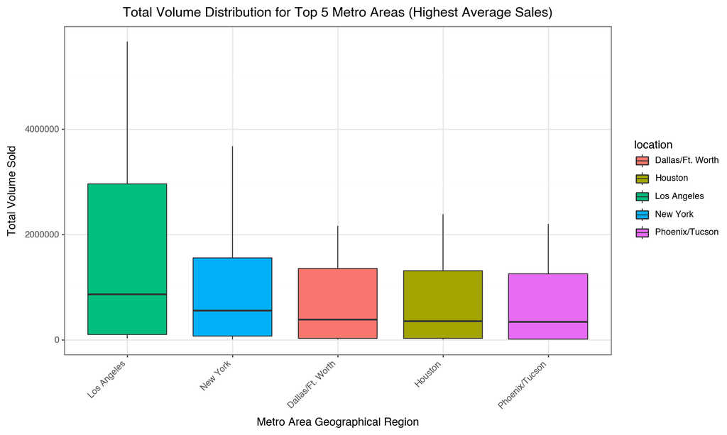

```python
#  Identify the top 5 metro areas (ordered list)
top_5_metros_avg = average_volume_by_metro.head(5).index.tolist()      #created a list?

#  Filter the city data for only these top 5 for plotting
df_top_5_avg = avocado_clean_city[avocado_clean_city['location'].isin(top_5_metros_avg)].copy()
# plotting boxplot

plot = (
    p9.ggplot(df_top_5_avg, p9.aes(x='location', y='total_volume', fill='location'))

    + p9.geom_boxplot()
    # descending order
    + p9.scale_x_discrete(limits=top_5_metros_avg)
    + p9.theme_bw()

    # labels
    + p9.labs(
        title='Total Volume Distribution for Top 5 Metro Areas (Highest Average Sales)',
        x='Metro Area Geographical Region',
        y='Total Volume Sold'
    )
    + p9.theme(
        axis_text_x=p9.element_text(angle=45, hjust=1),  #rotated the text on x axis
        figure_size=(10, 6)
    )
)
plot
```

# 6.

## From your cleaned data set, create a data set with only these California regions and answer the following questions about these California regions only.

The dataframe below includes the data from only 4 California regions (“Los Angeles”, “San Diego”, “Sacramento”, “San Francisco”)

```python
pd.options.display.float_format = '{:,.2f}'.format    #to keep the average price in float

# california regions list
california_regions = ["Los Angeles", "San Diego", "Sacramento", "San Francisco"]

# Filter with california regions, (used isin function for convenience)
california_df = avocado_clean[
    avocado_clean['location'].isin(california_regions)
].copy()

california_df
```

|  | date | average_price | type | location | total_volume | total_bags | small_bags | large_bags | xlarge_bags | hass_avacado_size | quantity_sold | geo_type | granular_region | year | month | day |
| --- | --- | --- | --- | --- | --- | --- | --- | --- | --- | --- | --- | --- | --- | --- | --- | --- |
| 44 | 2015-01-04 | 0.85 | conventional | Los Angeles | 2,682,159.95 | 255,504.05 | 215,571.80 | 36,981.72 | 2,950.53 | small | 1,837,999.65 | City | West | 2015 | 1 | 4 |
| 45 | 2015-01-04 | 1.25 | organic | Los Angeles | 54,495.54 | 5,050.63 | 5,050.63 | 0.00 | 0.00 | small | 47,721.51 | City | West | 2015 | 1 | 4 |
| 80 | 2015-01-04 | 1.05 | conventional | Sacramento | 430,138.88 | 39,600.08 | 39,600.08 | 0.00 | 0.00 | small | 110,693.69 | City | West | 2015 | 1 | 4 |
| 81 | 2015-01-04 | 1.33 | organic | Sacramento | 9,213.49 | 1,158.45 | 1,158.45 | 0.00 | 0.00 | small | 3,727.52 | City | West | 2015 | 1 | 4 |
| 82 | 2015-01-04 | 0.94 | conventional | San Diego | 461,607.33 | 36,852.99 | 30,884.29 | 5,595.00 | 373.70 | small | 244,152.26 | City | West | 2015 | 1 | 4 |
| ... | ... | ... | ... | ... | ... | ... | ... | ... | ... | ... | ... | ... | ... | ... | ... | ... |
| 99108 | 2020-11-29 | 1.43 | organic | Sacramento | 23,531.38 | 18,170.66 | 18,144.54 | 26.12 | 0.00 | extra_large | 0.00 | City | West | 2020 | 11 | 29 |
| 99109 | 2020-11-29 | 1.12 | conventional | San Diego | 469,356.72 | 337,647.81 | 189,341.36 | 127,701.64 | 20,604.81 | extra_large | 7,210.47 | City | West | 2020 | 11 | 29 |
| 99110 | 2020-11-29 | 1.95 | organic | San Diego | 25,799.95 | 24,067.21 | 9,691.46 | 14,375.75 | 0.00 | extra_large | 0.00 | City | West | 2020 | 11 | 29 |
| 99111 | 2020-11-29 | 1.50 | conventional | San Francisco | 644,141.37 | 373,270.49 | 159,276.65 | 207,760.32 | 6,233.52 | extra_large | 5,597.21 | City | West | 2020 | 11 | 29 |
| 99112 | 2020-11-29 | 1.87 | organic | San Francisco | 59,527.02 | 52,169.49 | 52,034.33 | 135.16 | 0.00 | extra_large | 0.00 | City | West | 2020 | 11 | 29 |

7344 rows × 16 columns

# 7.

## In which California regions is the price of organic versus conventional avocados most different? Support your answer with a few summary statistics AND a visualization.

## Summary statistics:

Calculating average price in different location catagorized by type i.e. organic/conventional (wide format dataset)

```python
# Calculate average price by location and type (Wide Format)
price_summary_wide = california_df.groupby(['location', 'type'])['average_price'].mean().unstack()
print(price_summary_wide)
```

```
type           conventional  organic
location
Los Angeles            1.05     1.57
Sacramento             1.30     1.87
San Diego              1.11     1.80
San Francisco          1.40     2.12
```

Calculating the differences between average organic avocado price and average conventional avocado price :

```python
price_summary_wide['price_difference'] = np.abs(price_summary_wide['organic'] - price_summary_wide['conventional'])
winner_region = price_summary_wide['price_difference'].idxmax()
print(price_summary_wide.sort_values('price_difference', ascending=False) )
```

```
type           conventional  organic  price_difference
location
San Francisco          1.40     2.12              0.72
San Diego              1.11     1.80              0.68
Sacramento             1.30     1.87              0.58
Los Angeles            1.05     1.57              0.53
```

Converting the wide summary into long format for plotting:

```python
# Convert the wide summary table back into the 'long' format required for plotting
plot_data_long = price_summary_wide[['organic', 'conventional']].stack().reset_index()
plot_data_long.columns = ['location', 'type', 'average_price']
print(plot_data_long)
```

```
        location          type  average_price
0    Los Angeles       organic           1.57
1    Los Angeles  conventional           1.05
2     Sacramento       organic           1.87
3     Sacramento  conventional           1.30
4      San Diego       organic           1.80
5      San Diego  conventional           1.11
6  San Francisco       organic           2.12
7  San Francisco  conventional           1.40
```

Ordered list for plotting:

```python
# Create an ordered list based on the calculated price difference (highest first)
# This list dictates the order of the bars on the X-axis
plot_order = price_summary_wide.sort_values(by='price_difference', ascending=False).index.tolist()
print(plot_order)
```

```
['San Francisco', 'San Diego', 'Sacramento', 'Los Angeles']
```

## Plotting

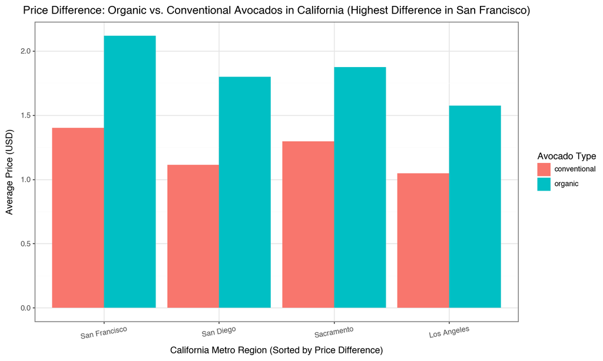

```python
plot = (
    # Map location to X, price to Y, and type to FILL (for grouping)
    p9.ggplot(plot_data_long, p9.aes(x='location', y='average_price', fill='type'))

    + p9.geom_col(position='dodge')

    # Set the order of the bars based on the calculated price difference
    + p9.scale_x_discrete(limits=plot_order)
    + p9.theme_bw()
    + p9.labs(
        title=f'Price Difference: Organic vs. Conventional Avocados in California (Highest Difference in {winner_region})',
        x='California Metro Region (Sorted by Price Difference)',
        y='Average Price (USD)',
        fill='Avocado Type'
    )
    + p9.theme(
        axis_text_x=p9.element_text(angle=10),
        figure_size=(10, 6)
    )
)
plot
```

### Answer: Therefore, San Fransisco experienced the highest differences in the price between organic and conventional avocados.

# 8.

## The following plot shows, for all four California regions, the proportion of the average Hass avocado sales that are small, large, or extra large; conventional vs. organic. Recreate the plot; you do not have to replicate the exact finishing touches - e.g., color, theme - but your plot should resemble the content of this plot.

Calculate the sum of volume (quantity_sold) for each Location and Type

```python
# Calculate the sum of volume (quantity_sold) for each Location and Type
total_volume_by_group = california_df.groupby(['location', 'type'])['quantity_sold'].sum().reset_index()

# Rename the volume column to clearly show it's the total
total_volume_by_group = total_volume_by_group.rename(columns={'quantity_sold': 'total_volume_group'})
```

Merge the total volume back into the main DataFrame

```python
# Merge the total volume back into the main DataFrame
df_proportions = pd.merge(
    california_df,
    total_volume_by_group,
    on=['location', 'type'],
    how='left'
)

# Calculate the proportion
df_proportions['proportion'] = df_proportions['quantity_sold'] / df_proportions['total_volume_group']
```

## Plotting

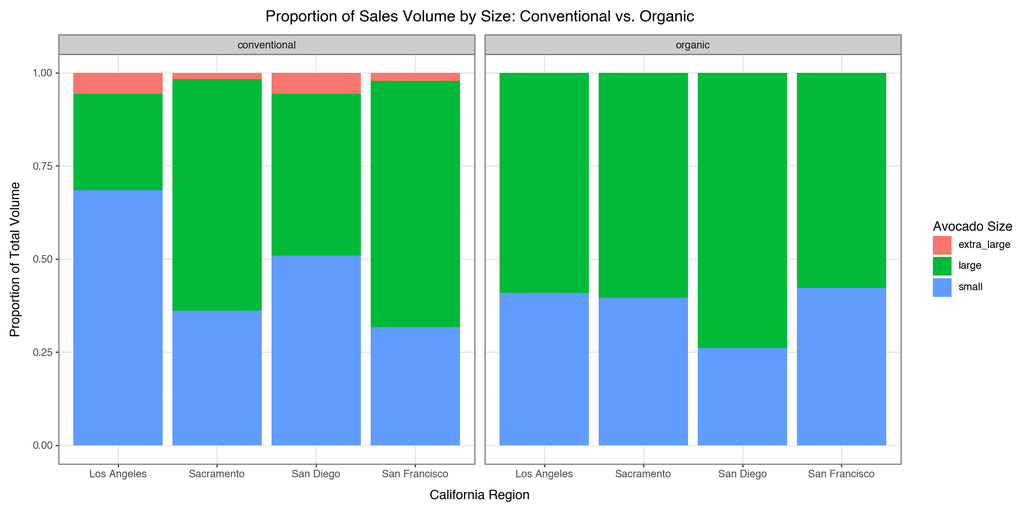

```python
plot_2 = (
    p9.ggplot(df_proportions, p9.aes(x='location', y='proportion', fill='hass_avacado_size'))

    # stat='identity' for pre-calculated proportions
    + p9.geom_bar(stat='identity', position='stack')

    # Separate the plot by conventional vs. organic
    + p9.facet_wrap('~ type')

    + p9.theme_bw()

    + p9.labs(
        title='Proportion of Sales Volume by Size: Conventional vs. Organic',
        x='California Region',
        y='Proportion of Total Volume',
        fill='Avocado Size'
    )
    + p9.theme(figure_size=(12, 6))
)
plot_2
```

# Using Outside Data

I am using monthly housing prices data from redfin as I was unable to find weekly data from 2015 - 2020. Therefore, I will convert the avocado dataset into monthly format by taking the mean sales to make dataset ready for comparitive analysis with housing prices in 4 california cities “Los Angeles”, “San Diego”, “Sacramento”, and “San Francisco”.

### Avocado data

1. Let’s create a new dataset (from avocado daatset) with filtered cities, and drop unuseful columns from avocado dataset (new dataset: ‘filtered_city_comparion_df’):

```python
#filter list
target_cities = ['San Francisco', 'San Diego', 'Sacramento', 'Los Angeles']
# boolean masking
city_filter = (
    (avocado_clean_city['geo_type'] == 'City') &
    (avocado_clean_city['location'].isin(target_cities))
)
#apply filter to new dataframe filtered_city_df
filtered_city_df = avocado_clean_city[city_filter].copy()
#copy 'filtered_city_df' to new datadframe 'filtered_city_comparion_df' to do the comparisons
filtered_city_comparion_df = filtered_city_df[['date', 'location', 'total_volume']].copy().reset_index()
filtered_city_comparion_df
```

|  | index | date | location | total_volume |
| --- | --- | --- | --- | --- |
| 0 | 44 | 2015-01-04 | Los Angeles | 2,682,159.95 |
| 1 | 45 | 2015-01-04 | Los Angeles | 54,495.54 |
| 2 | 80 | 2015-01-04 | Sacramento | 430,138.88 |
| 3 | 81 | 2015-01-04 | Sacramento | 9,213.49 |
| 4 | 82 | 2015-01-04 | San Diego | 461,607.33 |
| ... | ... | ... | ... | ... |
| 7339 | 99108 | 2020-11-29 | Sacramento | 23,531.38 |
| 7340 | 99109 | 2020-11-29 | San Diego | 469,356.72 |
| 7341 | 99110 | 2020-11-29 | San Diego | 25,799.95 |
| 7342 | 99111 | 2020-11-29 | San Francisco | 644,141.37 |
| 7343 | 99112 | 2020-11-29 | San Francisco | 59,527.02 |

7344 rows × 4 columns

2. Calculating mean based on months and years

```python
#convert date, month, year in right format
filtered_city_comparion_df['date'] = pd.to_datetime(filtered_city_comparion_df['date'], errors='coerce')
#filter year and month
filtered_city_comparion_df['year'] = filtered_city_comparion_df['date'].dt.year
filtered_city_comparion_df['month'] = filtered_city_comparion_df['date'].dt.month

#apply filters in the new dataframe

monthly_city_mean = (
    filtered_city_comparion_df
    .groupby(['location', 'year', 'month'])['total_volume']
    .mean()
    .reset_index()
    .rename(columns={'total_volume': 'monthly_mean_total_volume'})
)
print(monthly_city_mean)
```

```
          location  year  month  monthly_mean_total_volume
0      Los Angeles  2015      1               1,340,372.71
1      Los Angeles  2015      2               1,592,214.84
2      Los Angeles  2015      3               1,382,745.03
3      Los Angeles  2015      4               1,354,605.72
4      Los Angeles  2015      5               1,640,057.84
..             ...   ...    ...                        ...
279  San Francisco  2020      7                 569,584.05
280  San Francisco  2020      8                 586,782.15
281  San Francisco  2020      9                 539,353.03
282  San Francisco  2020     10                 511,774.07
283  San Francisco  2020     11                 456,609.86

[284 rows x 4 columns]
```

### Housing price data (from Redfin)

cleaning the data (filtering the required cities, melting the dataset to long format, getting rid of $, K, ‘,’ and conveting the ’date format to datetime)

```python
import pandas as pd

# 1. read data
housing_sales_df = pd.read_csv('housing_sales.csv', encoding='utf-16', delimiter='\t')  #data was not separated with ','

# list of the desired cities
target_housing_cities = [
    'Los Angeles, CA metro area', 'Sacramento, CA',
    'San Diego, CA', 'San Francisco, CA'
]
# filtering location column(unnamed:0) with the list 'target_housing_cities'
housing_sales_df = housing_sales_df[housing_sales_df['Unnamed: 0'].isin(target_housing_cities)]


# 2. Get value columns and mapping for month/year
value_columns = [col for col in housing_sales_df.columns if col != 'Unnamed: 0']
date_range = pd.date_range('2015-01-01', '2020-12-01', freq='MS')
col_to_date = dict(zip(value_columns, date_range))

# 3. Melt to tidy long format and map column names to real dates
housing_sales_long = pd.melt(
    housing_sales_df,
    id_vars=['Unnamed: 0'],
    value_vars=value_columns,
    var_name='date_col',
    value_name='housing_price'
)
housing_sales_long = housing_sales_long.rename(columns={'Unnamed: 0': 'location'})
housing_sales_long['date'] = housing_sales_long['date_col'].map(col_to_date)
housing_sales_long = housing_sales_long.drop(columns=['date_col'])

# 4. Filter only rows that contain $ (i.e., real price values)
housing_sales_long = housing_sales_long[
    housing_sales_long['housing_price'].str.contains(r'\$', na=False, regex=True)
]

# 5. Clean, remove $/K/commas, and convert to float dollars
housing_sales_long['housing_price'] = (
    housing_sales_long['housing_price']
        .str.replace('$', '', regex=False)
        .str.replace('K', '', regex=False)
        .str.replace(',', '', regex=False)
        .astype(float) * 1000
)

# 6. Add year and month columns for easy merging/aggregation
housing_sales_long['year'] = housing_sales_long['date'].dt.year
housing_sales_long['month'] = housing_sales_long['date'].dt.month

print(housing_sales_long.head())
```

```
                     location  housing_price       date  year  month
0  Los Angeles, CA metro area     470,000.00 2015-01-01  2015      1
1              Sacramento, CA     254,000.00 2015-01-01  2015      1
2               San Diego, CA     480,000.00 2015-01-01  2015      1
3           San Francisco, CA   1,133,000.00 2015-01-01  2015      1
4  Los Angeles, CA metro area     480,000.00 2015-02-01  2015      2
```

### Comparing the 2 datastes (Avocado and housing price in California cities)

Merging the 2 dataset on similar cities(merging the city names from both datasets)

```python
# dictionary to merge city names from both datasets
city_name_map = {
    'Los Angeles': 'Los Angeles, CA metro area',
    'Sacramento': 'Sacramento, CA',
    'San Diego': 'San Diego, CA',
    'San Francisco': 'San Francisco, CA'
}
# 'monthly_city_mean' from avocado dataset
#mapping the new dict to avocado dataset
monthly_city_mean['location_mapped'] = monthly_city_mean['location'].map(city_name_map)

# Merge avocado and housing data on matching columns
joined_df = pd.merge(
    monthly_city_mean,
    housing_sales_long,
    left_on=['location_mapped', 'year', 'month'],
    right_on=['location', 'year', 'month'],
    how='inner'
)
```

### Plotting

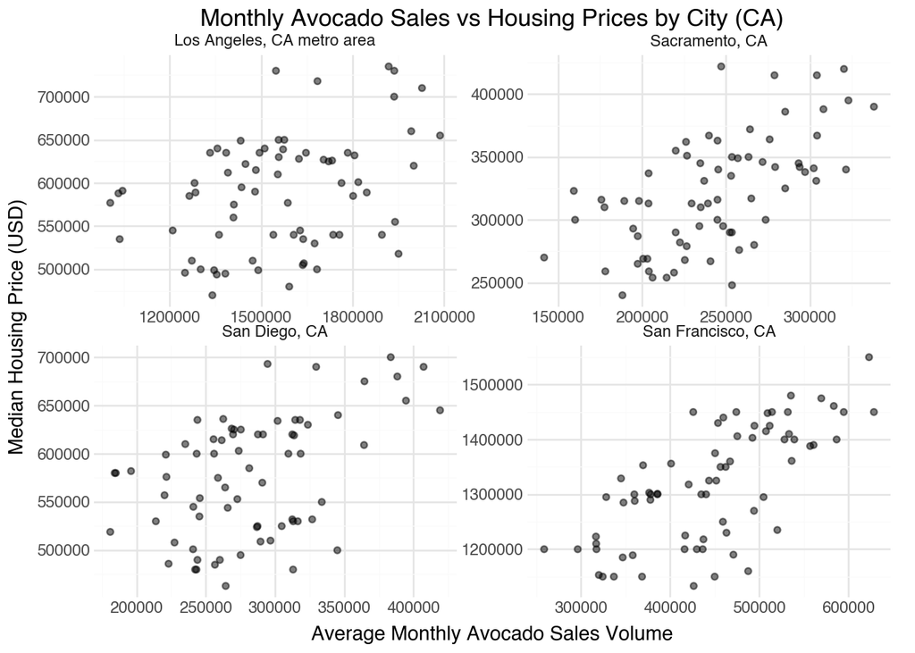

```python
# Scatter plot: avocado sales vs. house prices, faceted by CA city
(
    p9.ggplot(joined_df, p9.aes(x='monthly_mean_total_volume', y='housing_price')) +
    p9.geom_point(alpha=0.5) +
    p9.facet_wrap('~location_y', scales='free') +   # <-- use location_y for faceting!
    p9.labs(
        title='Monthly Avocado Sales vs Housing Prices by City (CA)',
        x='Average Monthly Avocado Sales Volume',
        y='Median Housing Price (USD)'
    ) +
    p9.theme_minimal()
)
```

```python
import pandas as pd
from scipy.stats import pearsonr
import statsmodels.api as sm

correlation_results = []
regression_results = []

for city in joined_df['location_y'].unique():
    subset = joined_df[joined_df['location_y'] == city].dropna(subset=['monthly_mean_total_volume', 'housing_price'])
    if len(subset) >= 2:  # avoid too short
        # Pearson correlation
        corr, pval = pearsonr(subset['monthly_mean_total_volume'], subset['housing_price'])
        correlation_results.append({'city': city, 'pearson_r': corr, 'p_value': pval})
        # Linear regression (housing_price ~ monthly_mean_total_volume)
        X = subset['monthly_mean_total_volume']
        y = subset['housing_price']
        X = sm.add_constant(X)
        model = sm.OLS(y, X).fit()
        regression_results.append({
            'city': city,
            'reg_coef': model.params['monthly_mean_total_volume'],
            'intercept': model.params['const'],
            'r_squared': model.rsquared,
            'p_value': model.pvalues['monthly_mean_total_volume']
        })

pd.DataFrame(correlation_results)
pd.DataFrame(regression_results)
```

|  | city | reg_coef | intercept | r_squared | p_value |
| --- | --- | --- | --- | --- | --- |
| 0 | Los Angeles, CA metro area | 0.09 | 445,899.52 | 0.12 | 0.00 |
| 1 | Sacramento, CA | 0.64 | 166,818.48 | 0.37 | 0.00 |
| 2 | San Diego, CA | 0.54 | 425,029.97 | 0.21 | 0.00 |
| 3 | San Francisco, CA | 0.85 | 936,065.08 | 0.48 | 0.00 |

# Annotatons:

1. Used Gemini to understand the dataset(avocado time series dataset), specifically the columns with small_bags, large-bags,..etc and how they differ from the ‘total_volumns’, ‘4046’, ‘4225’,..etc.
2. used gemini to create the dictionaries for queston 3 and 5 to assign the reions and geo_types from ‘locatoion’ column from the original dataset.
3. used gemini to debug the code, understand the porcess, get insights and ideas for how to approach the problem.
4. in a few problems, i asked gemini to provide me with the code and explain it to me with context. I used that code after modifying it to answer the question.
5. used perplexity to code for last part(using outside data), but understood what it is doing
6. imported housing price data from Redfin